# White wine exploration by Stefan Langenbach

## Udacity data analyst nanodegree

The dataset we are going to investigate consists of roughly 4.900 records of white wines and 12 attributes specifying their (chemical) properties, i.e. acidity, pH-level, alcohol-percentage and quality rating. Each wine was rated by at least 3 experts in order to provide a quality score. The score ranges from 0 (worst) to 10 (best).

```
## 'data.frame':    4898 obs. of  13 variables:
##  $ X                   : int  1 2 3 4 5 6 7 8 9 10 ...
##  $ fixed.acidity       : num  7 6.3 8.1 7.2 7.2 8.1 6.2 7 6.3 8.1 ...
##  $ volatile.acidity    : num  0.27 0.3 0.28 0.23 0.23 0.28 0.32 0.27 0.3 0.22 ...
##  $ citric.acid         : num  0.36 0.34 0.4 0.32 0.32 0.4 0.16 0.36 0.34 0.43 ...
##  $ residual.sugar      : num  20.7 1.6 6.9 8.5 8.5 6.9 7 20.7 1.6 1.5 ...
##  $ chlorides           : num  0.045 0.049 0.05 0.058 0.058 0.05 0.045 0.045 0.049 0.044 ...
##  $ free.sulfur.dioxide : num  45 14 30 47 47 30 30 45 14 28 ...
##  $ total.sulfur.dioxide: num  170 132 97 186 186 97 136 170 132 129 ...
##  $ density             : num  1.001 0.994 0.995 0.996 0.996 ...
##  $ pH                  : num  3 3.3 3.26 3.19 3.19 3.26 3.18 3 3.3 3.22 ...
##  $ sulphates           : num  0.45 0.49 0.44 0.4 0.4 0.44 0.47 0.45 0.49 0.45 ...
##  $ alcohol             : num  8.8 9.5 10.1 9.9 9.9 10.1 9.6 8.8 9.5 11 ...
##  $ quality             : int  6 6 6 6 6 6 6 6 6 6 ...
```

The dataset does not contain any missing values.

```
## [1] 0
```

Investigating summary statistics for our dataset, it is obvious that some of the variables contain extreme values. For example: The maximum value for residual sugar is roughly 12.5 times the median. Other variables containing extreme values are chlorides (maximum value is roughly 8 times median value), and free.sulfur.dioxide. Another interesting insight is that no wine reached the maximum quality rating of 10.

```
##        X        fixed.acidity    volatile.acidity  citric.acid
##  Min.   :   1   Min.   : 3.800   Min.   :0.0800   Min.   :0.0000
##  1st Qu.:1225   1st Qu.: 6.300   1st Qu.:0.2100   1st Qu.:0.2700
##  Median :2450   Median : 6.800   Median :0.2600   Median :0.3200
##  Mean   :2450   Mean   : 6.855   Mean   :0.2782   Mean   :0.3342
##  3rd Qu.:3674   3rd Qu.: 7.300   3rd Qu.:0.3200   3rd Qu.:0.3900
##  Max.   :4898   Max.   :14.200   Max.   :1.1000   Max.   :1.6600
##  residual.sugar     chlorides       free.sulfur.dioxide
##  Min.   : 0.600   Min.   :0.00900   Min.   :  2.00
##  1st Qu.: 1.700   1st Qu.:0.03600   1st Qu.: 23.00
##  Median : 5.200   Median :0.04300   Median : 34.00
##  Mean   : 6.391   Mean   :0.04577   Mean   : 35.31
##  3rd Qu.: 9.900   3rd Qu.:0.05000   3rd Qu.: 46.00
##  Max.   :65.800   Max.   :0.34600   Max.   :289.00
##  total.sulfur.dioxide    density             pH          sulphates
##  Min.   :  9.0        Min.   :0.9871   Min.   :2.720   Min.   :0.2200
##  1st Qu.:108.0        1st Qu.:0.9917   1st Qu.:3.090   1st Qu.:0.4100
##  Median :134.0        Median :0.9937   Median :3.180   Median :0.4700
##  Mean   :138.4        Mean   :0.9940   Mean   :3.188   Mean   :0.4898
##  3rd Qu.:167.0        3rd Qu.:0.9961   3rd Qu.:3.280   3rd Qu.:0.5500
##  Max.   :440.0        Max.   :1.0390   Max.   :3.820   Max.   :1.0800
##     alcohol         quality
##  Min.   : 8.00   Min.   :3.000
##  1st Qu.: 9.50   1st Qu.:5.000
##  Median :10.40   Median :6.000
##  Mean   :10.51   Mean   :5.878
##  3rd Qu.:11.40   3rd Qu.:6.000
##  Max.   :14.20   Max.   :9.000
```

# Univariate Plots Section

Let’s move on with a visual investigation of our dataset. The following plots will investigate each variable individually.

## Non-chemical variables

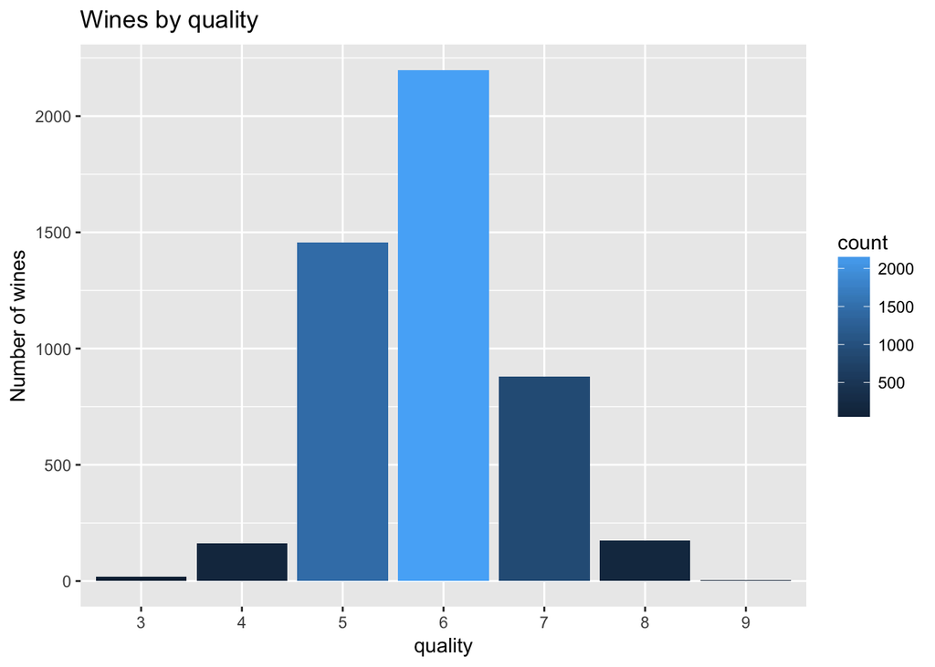

Wine rating ranges from 3 to 9 and most wines were given a rating of 6. There are only very few wines with particularly bad (quality = 3) or good (quality = 9) ratings.

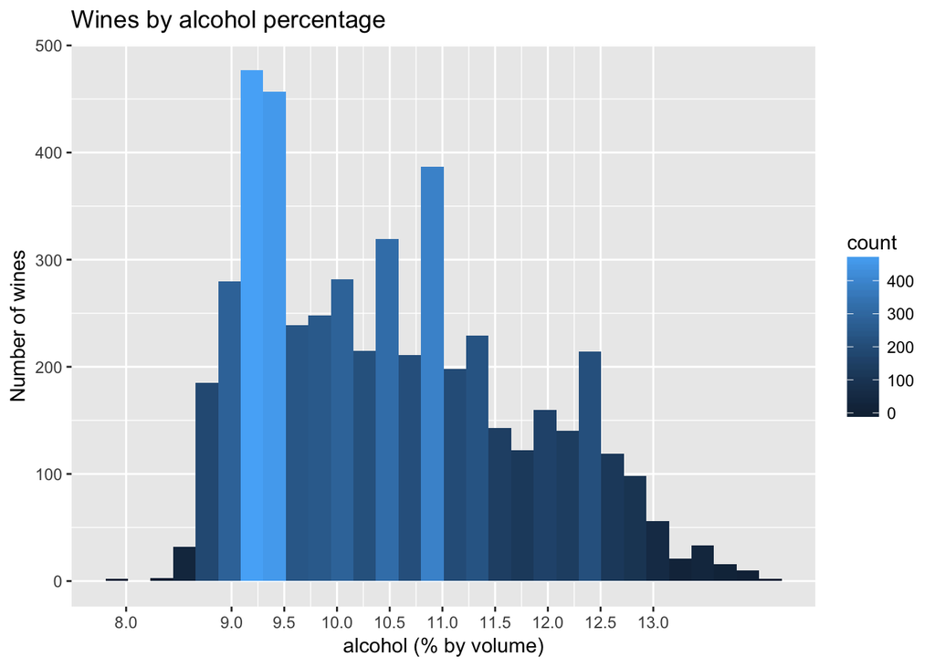

```
##    Min. 1st Qu.  Median    Mean 3rd Qu.    Max.
##    8.00    9.50   10.40   10.51   11.40   14.20
```

The distribution of percentage of alcohol of wines in the dataset is multi-modal. Although most wines have between 9 and 9.5% of alcohol, there are more peaks 10.5, close to 11 and close to 12.5.

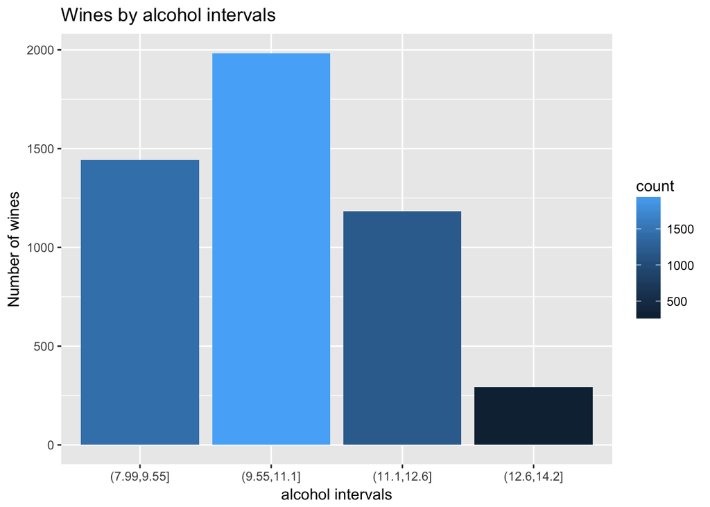

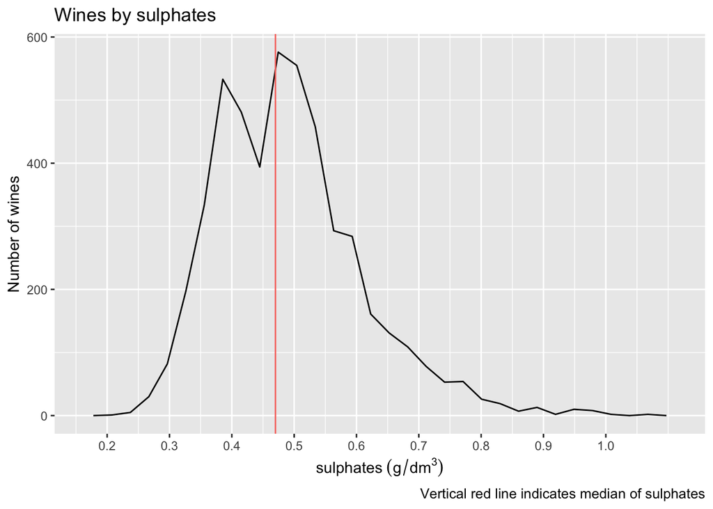

```
##    Min. 1st Qu.  Median    Mean 3rd Qu.    Max.
##  0.2200  0.4100  0.4700  0.4898  0.5500  1.0800
```

Interestingly, sulphates has a bi-modal distribution with peaks at about 0.375 and 0.475. Furthermore there are few wines with high values of sulphates (above 0.85).

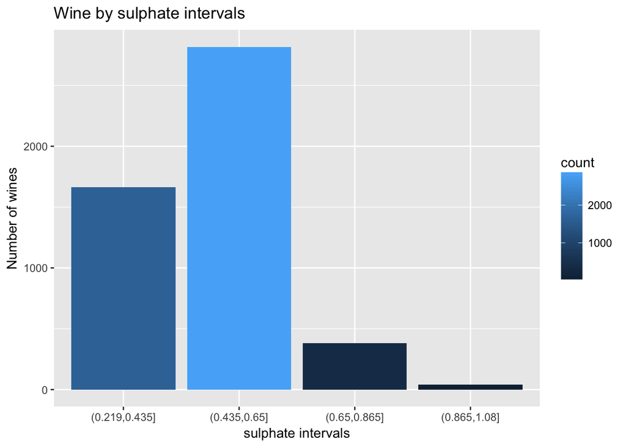

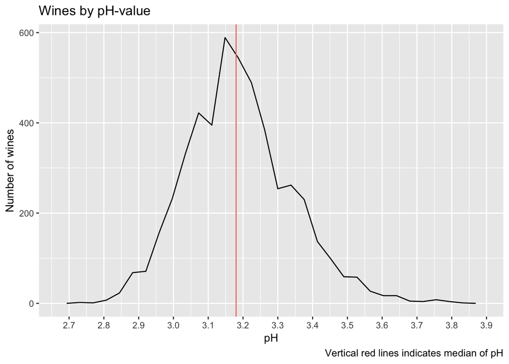

pH values seem to be almost normally distributed with a peak at 3.15. The distribution has a longer tail at the right side.

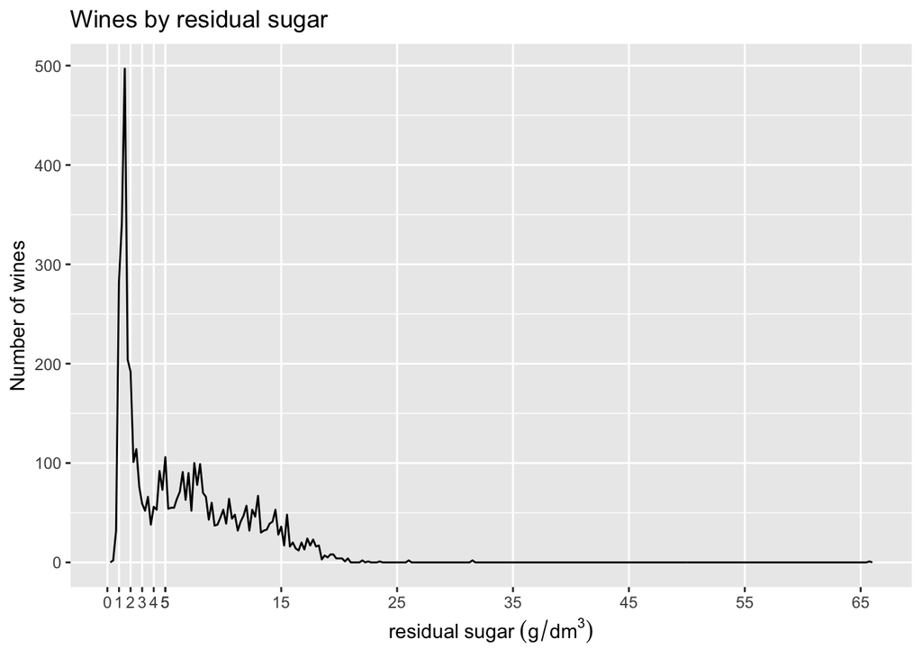

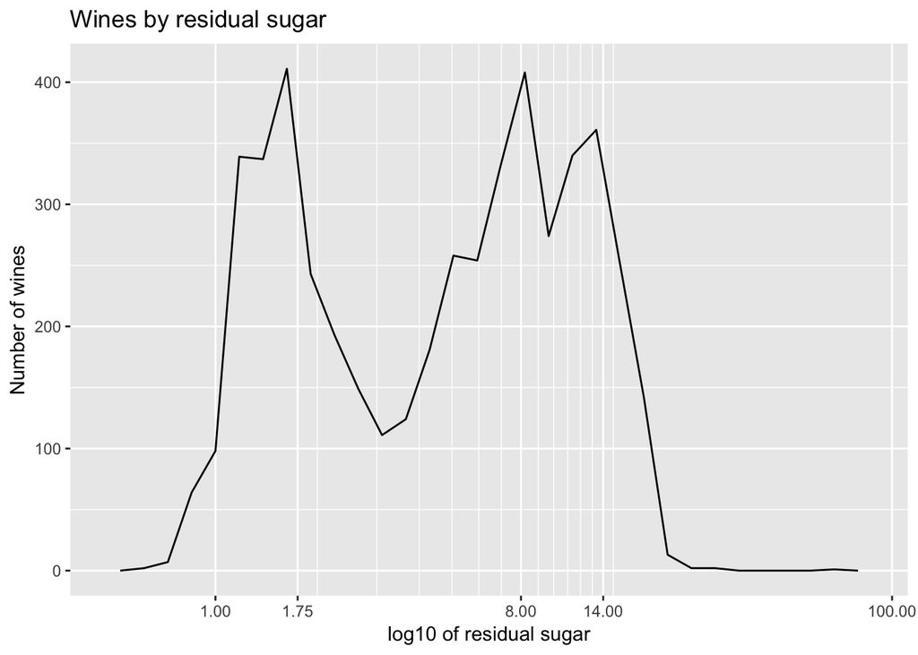

```
##    Min. 1st Qu.  Median    Mean 3rd Qu.    Max.
##   0.600   1.700   5.200   6.391   9.900  65.800
```

As already observed during investigation of summary statistics, residual.sugar contains extreme values, thus skewing standard plots without scaling of the x-axis. The plot above uses a log10-scaled x-axis and provides better insight into the distribution of residual sugar. It appears to be multi-modal with peaks at roughly 1.75, 8 and 14.

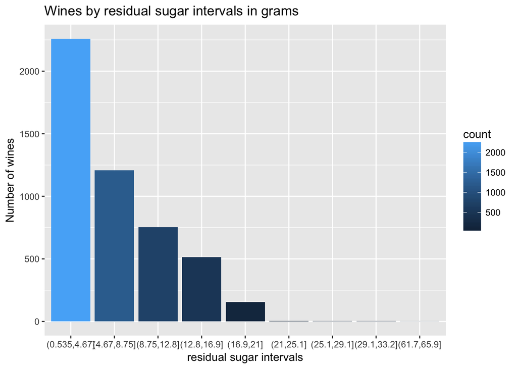

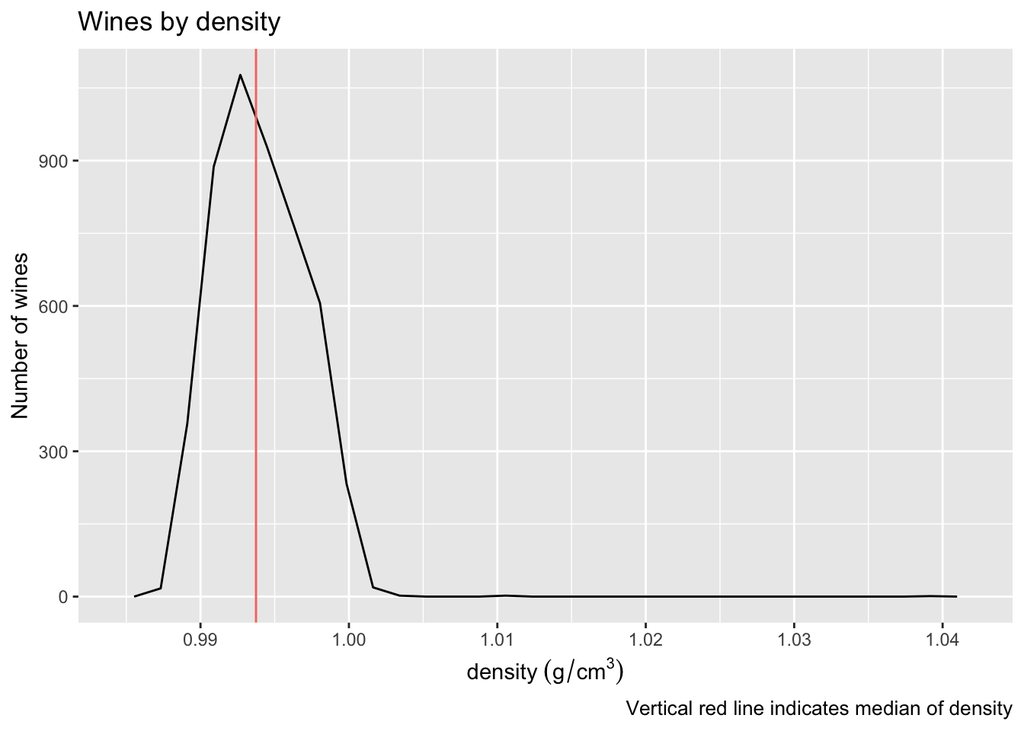

Most wines have a density close to 1.

## Chemical variables

Let’s also investigate the remaining chemical variables:

- fixed.acidity
- volatile.acidity
- citric.acid
- chlorides
- free.sulfur.dioxide
- total.sulfur.dioxide

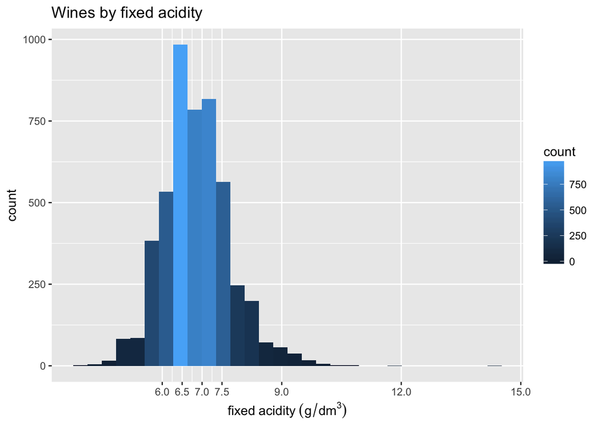

For most wines fixed acidity lies between 6 and 7.25 with two peaks at 6.5 and 7.25

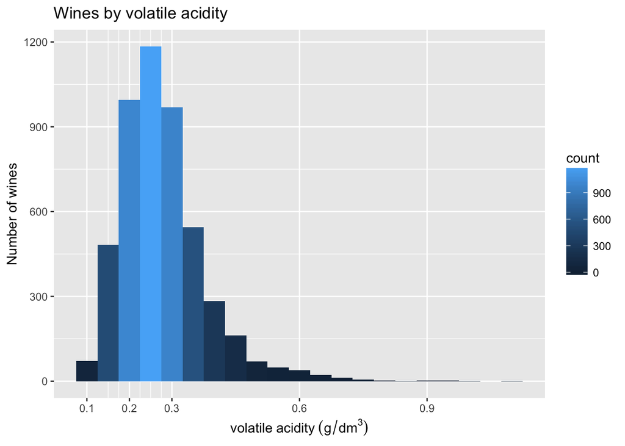

Volatile acidity peaks at roughly 0.25 for most wines, but there are two additional plateaus at about 0.2 and 0.3.

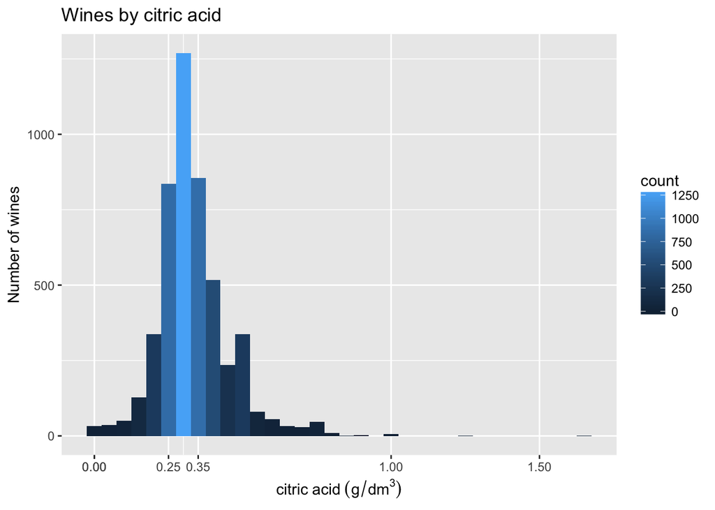

```
##    Min. 1st Qu.  Median    Mean 3rd Qu.    Max.
##  0.0000  0.2700  0.3200  0.3342  0.3900  1.6600
```

Majority of wines have a concentration of citric acid ranging from 0.25 to 0.35. The maximum value is 1.66, which is roughly 5 times the median.

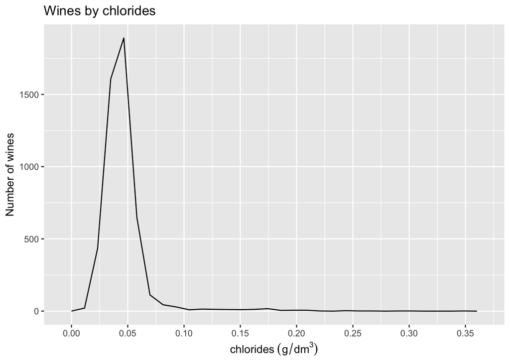

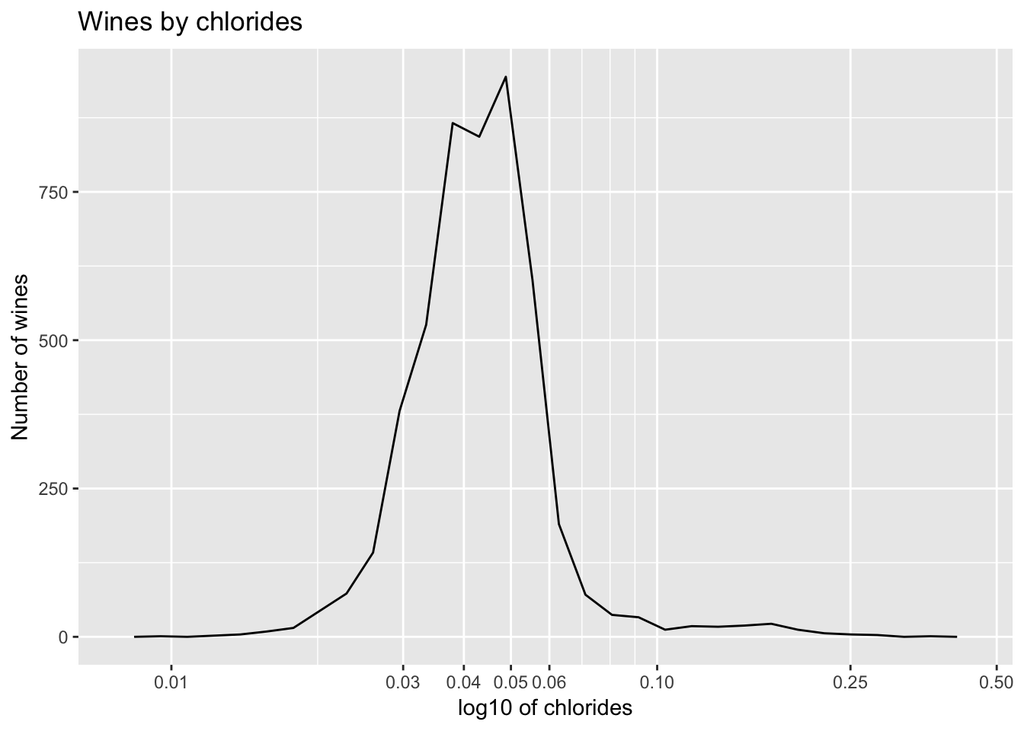

```
##    Min. 1st Qu.  Median    Mean 3rd Qu.    Max.
## 0.00900 0.03600 0.04300 0.04577 0.05000 0.34600
```

Similar to residual.sugar, chlorides contains extreme values, thus skewing standard plots without scaling of the x-axis. The plot above uses a log10-scaled x-axis and provides better insight into the distribution of chlorides. Most wines have concentration of chlorides between 0.03 and 0.06.

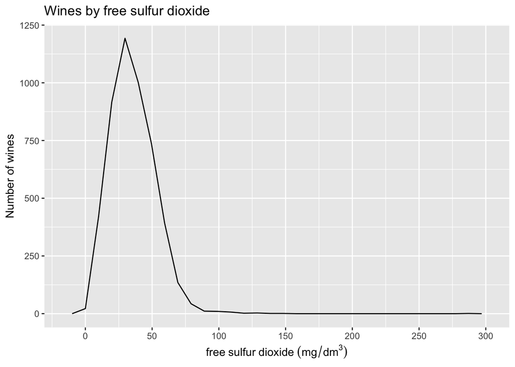

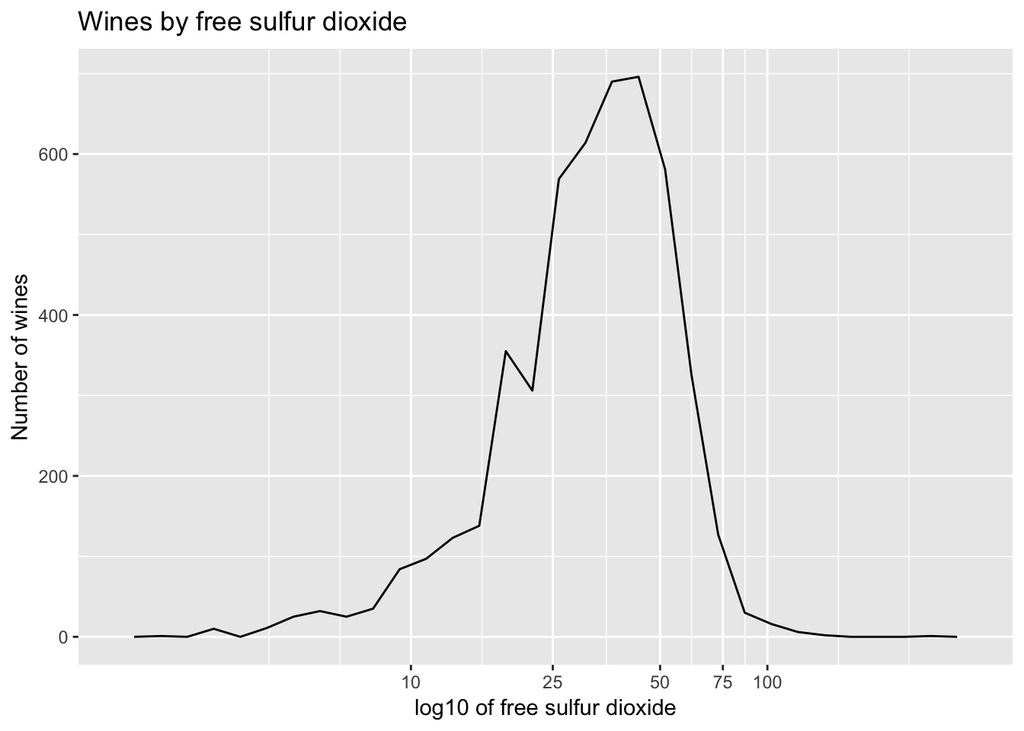

```
##    Min. 1st Qu.  Median    Mean 3rd Qu.    Max.
##    2.00   23.00   34.00   35.31   46.00  289.00
```

Also free sulfur dioxide contains extreme values and thus the x-axis has been scaled to log10. Most wines have concentration of free sulfur dioxides between 25 and 50.

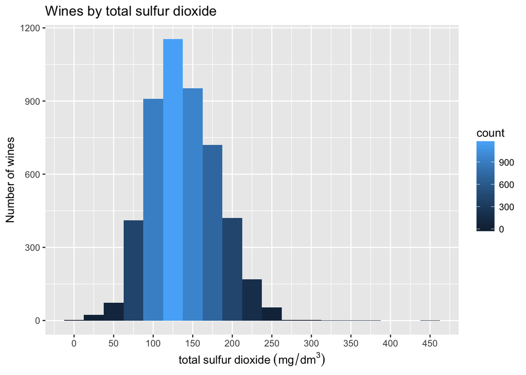

```
##    Min. 1st Qu.  Median    Mean 3rd Qu.    Max.
##     9.0   108.0   134.0   138.4   167.0   440.0
```

Most wines contain between 100 and 150mg of sulfur dioxide. There is one wine with a value three more than 3 time the median, i.e. 440.

# Univariate Analysis

### What is the structure of your dataset?

The dataset contains roughly 4.900 observations and 12 variables (X is just an index). The variable quality is an ordered factor ranging from 0 (worst) to 10 (best).

Additional observations:

- No wine has a quality rating below 3, none has one above 9
- Most wines contain between 9 and 11% of alcohol
- Median for residual sugar is 5.2g, but there is one wine with 65g
- Sulphates has a bi-modal distribution

### What is/are the main feature(s) of interest in your dataset?

The main features to predict quality should be alcohol, residual sugar and sulphates.

### What other features in the dataset do you think will help support your investigation into your feature(s) of interest?

A combination of pure chemical features, i.e. free sulfur dioxide, chlorides and some measure of acidity, could also have an effect on quality

### Did you create any new variables from existing variables in the dataset?

I created factors for my main variables of interest (alcohol, residual sugar and sulphates) using cut with break points

# Bivariate Plots Section and analysis

Before investigating relationships among the main features of the dataset and wine quality, let us check correlations among all variables:

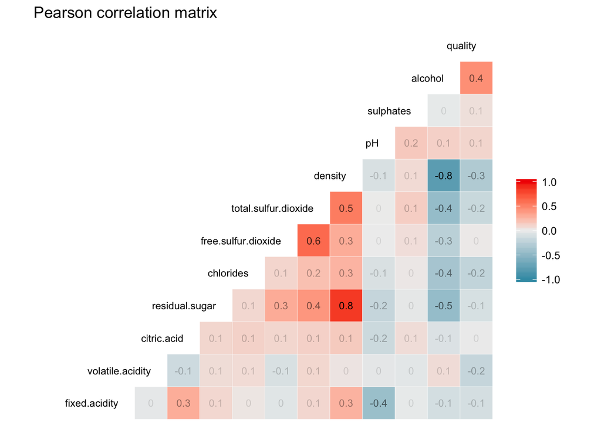

Apparently there exist only a moderately strong positive correlation between quality and alcohol. All other variables seem to be either unrelated or moderately negatively correlated (density) with quality. Consequently I will limit my bivariate analysis to relationships between

- quality and alcohol
- quality and density
- density and alcohol
- density and residual sugar

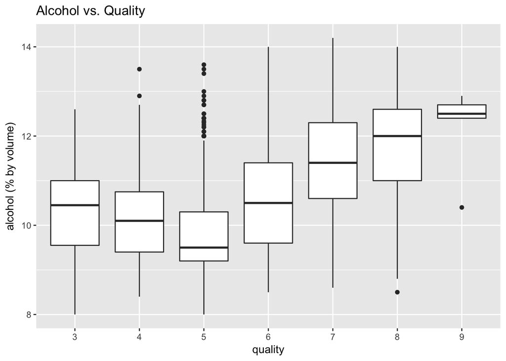

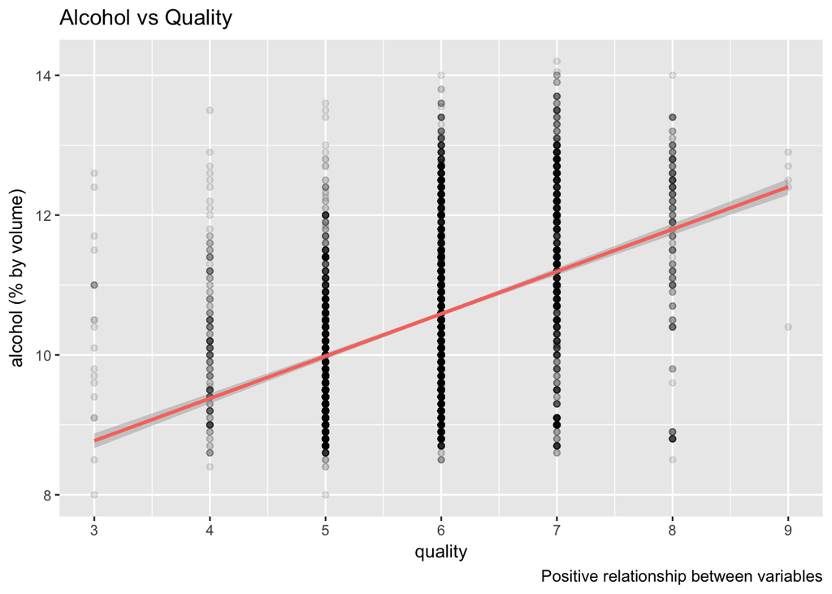

Generally we can observe a moderate trend of rising levels of alcohol concentration given increasing quality ratings. Although alcohol concentration decreases when moving from quality ratings of 3 to those of 4 and 5, the existence of outliers for these quality ratings indicates that there exists a slight positive trend.

[figure not shown]

The further quality ratings increase, the lower density becomes.

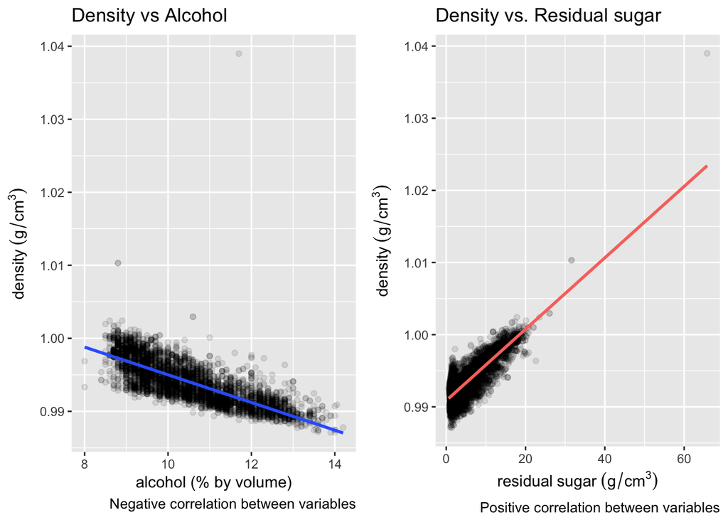

Both scatter plots visualize what has been revealed by the correlation matrix: Strong negative/positive relationships between density and alcohol/residual sugar

### Talk about some of the relationships you observed in this part of the investigation. How did the feature(s) of interest vary with other features in the dataset?

As the correlation matrix revealed, only quality and alcohol have a moderate positive relationship.

### Did you observe any interesting relationships between the other features (not the main feature(s) of interest)?

There is a strong positive relationship between density and residual sugar, as well as a strong negative relationship between density and alcohol. The latter makes sense to me, given the explanation from wineQualityInfo.txt: “the density of wine is close to that of water depending on the percent alcohol and sugar content”. Therefore, as alcohol concentration increases, density decreases.

### What was the strongest relationship you found?

As mentioned above, the strongest correlations (+/- 0.8) are those between density and alcohol and density and residual.

# Multivariate Plots Section

Let’s have a look at the relationship between alcohol, quality and density:

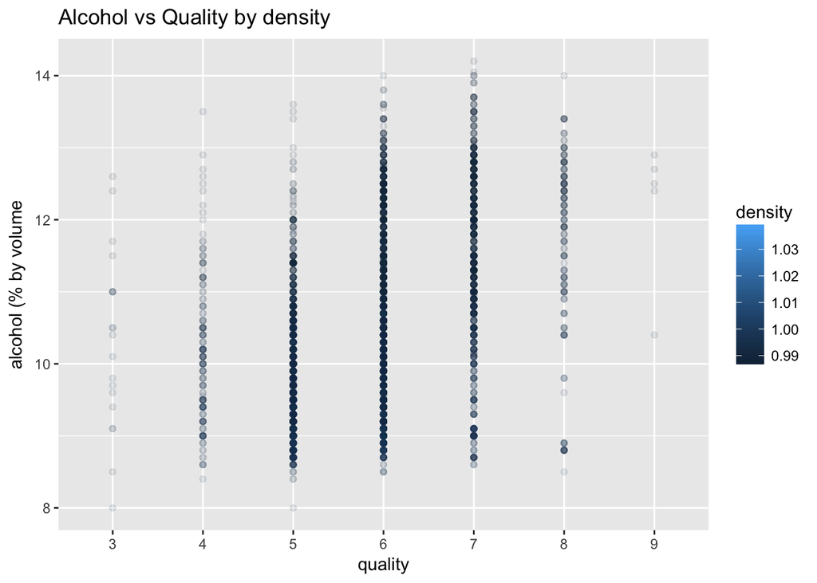

If we inspect the plot closely we do see higher concentrations of alcohol associated with higher quality rating and lower values for density.

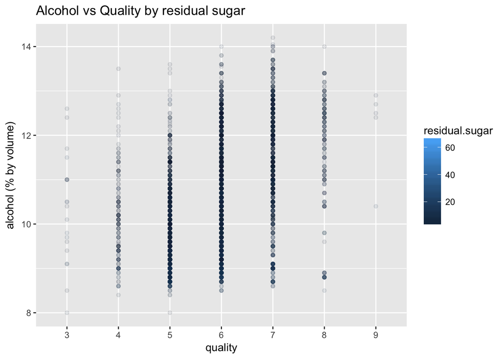

# Multivariate Analysis

Model is based on the assumptions I outlined in the univariate plots section, i.e. that alcohol, sulphates and residual sugar would be predictors of quality, and the insights from the correlation matrix. The results show, that a model solely based on alcohol is equally good (or worse taking into account adjusted R^2 values of roughly only 0.22 (lm1), 0.19 (lm2), 0.21 (lm3) and 0.19 (lm4).

```
##
## Call:
## lm(formula = quality ~ alcohol + sulphates + residual.sugar +
##     density, data = wine)
##
## Residuals:
##     Min      1Q  Median      3Q     Max
## -3.4140 -0.5337 -0.0231  0.4719  3.2399
##
## Coefficients:
##                  Estimate Std. Error t value Pr(>|t|)
## (Intercept)     1.153e+02  1.276e+01   9.034  < 2e-16 ***
## alcohol         2.175e-01  1.855e-02  11.723  < 2e-16 ***
## sulphates       7.532e-01  1.019e-01   7.393 1.69e-13 ***
## residual.sugar  6.317e-02  5.235e-03  12.068  < 2e-16 ***
## density        -1.132e+02  1.272e+01  -8.897  < 2e-16 ***
## ---
## Signif. codes:  0 '***' 0.001 '**' 0.01 '*' 0.05 '.' 0.1 ' ' 1
##
## Residual standard error: 0.783 on 4893 degrees of freedom
## Multiple R-squared:  0.2189, Adjusted R-squared:  0.2183
## F-statistic: 342.8 on 4 and 4893 DF,  p-value: < 2.2e-16
```

```
##
## Call:
## lm(formula = quality ~ alcohol + density, data = wine)
##
## Residuals:
##     Min      1Q  Median      3Q     Max
## -3.5670 -0.5242 -0.0003  0.4881  3.0898
##
## Coefficients:
##              Estimate Std. Error t value Pr(>|t|)
## (Intercept) -22.49170    6.16503  -3.648 0.000267 ***
## alcohol       0.36036    0.01478  24.389  < 2e-16 ***
## density      24.72842    6.07937   4.068 4.82e-05 ***
## ---
## Signif. codes:  0 '***' 0.001 '**' 0.01 '*' 0.05 '.' 0.1 ' ' 1
##
## Residual standard error: 0.796 on 4895 degrees of freedom
## Multiple R-squared:  0.1925, Adjusted R-squared:  0.1921
## F-statistic: 583.3 on 2 and 4895 DF,  p-value: < 2.2e-16
```

```
##
## Call:
## lm(formula = quality ~ alc_level + sul_level + sugar_level +
##     density, data = wine)
##
## Residuals:
##     Min      1Q  Median      3Q     Max
## -3.3678 -0.5184  0.0290  0.4918  3.2789
##
## Coefficients:
##                          Estimate Std. Error t value Pr(>|t|)
## (Intercept)             136.67228   11.18306  12.221  < 2e-16 ***
## alc_level(9.55,11.1]      0.19029    0.03265   5.828 5.95e-09 ***
## alc_level(11.1,12.6]      0.48944    0.05076   9.642  < 2e-16 ***
## alc_level(12.6,14.2]      0.72659    0.07463   9.737  < 2e-16 ***
## sul_level(0.435,0.65]     0.08868    0.02510   3.533 0.000415 ***
## sul_level(0.65,0.865]     0.24208    0.04608   5.254 1.55e-07 ***
## sul_level(0.865,1.08]     0.40214    0.12826   3.135 0.001727 **
## sugar_level(4.67,8.75]    0.30085    0.03428   8.775  < 2e-16 ***
## sugar_level(8.75,12.8]    0.55645    0.05050  11.018  < 2e-16 ***
## sugar_level(12.8,16.9]    0.92005    0.06639  13.859  < 2e-16 ***
## sugar_level(16.9,21]      0.89137    0.09463   9.420  < 2e-16 ***
## sugar_level(21,25.1]      0.28777    0.40422   0.712 0.476543
## sugar_level(25.1,29.1]    1.71047    0.57132   2.994 0.002768 **
## sugar_level(29.1,33.2]    2.87230    0.58970   4.871 1.15e-06 ***
## sugar_level(61.7,65.9]    5.93179    0.95617   6.204 5.97e-10 ***
## density                -132.18310   11.25372 -11.746  < 2e-16 ***
## ---
## Signif. codes:  0 '***' 0.001 '**' 0.01 '*' 0.05 '.' 0.1 ' ' 1
##
## Residual standard error: 0.7896 on 4882 degrees of freedom
## Multiple R-squared:  0.2076, Adjusted R-squared:  0.2051
## F-statistic: 85.25 on 15 and 4882 DF,  p-value: < 2.2e-16
```

```
##
## Call:
## lm(formula = quality ~ alcohol, data = wine)
##
## Residuals:
##     Min      1Q  Median      3Q     Max
## -3.5317 -0.5286  0.0012  0.4996  3.1579
##
## Coefficients:
##             Estimate Std. Error t value Pr(>|t|)
## (Intercept) 2.582009   0.098008   26.34   <2e-16 ***
## alcohol     0.313469   0.009258   33.86   <2e-16 ***
## ---
## Signif. codes:  0 '***' 0.001 '**' 0.01 '*' 0.05 '.' 0.1 ' ' 1
##
## Residual standard error: 0.7973 on 4896 degrees of freedom
## Multiple R-squared:  0.1897, Adjusted R-squared:  0.1896
## F-statistic:  1146 on 1 and 4896 DF,  p-value: < 2.2e-16
```

### Talk about some of the relationships you observed in this part of the investigation. Were there features that strengthened each other in terms of looking at your feature(s) of interest?

The visual representation of alcohol vs quality by density or residual sugar did unfortunately not offer any new insights)

### Were there any interesting or surprising interactions between features?

No, as revealed by the correlation matrix, quality is only moderately strong related to alcohol and density. Therefore investigating other variables did not bring any new insights

### Did you create any models with your dataset? Discuss the strengths and limitations of your model.

The four linear models I created a very simple and do not predict quality well.

# Final Plots and Summary

### Plot One

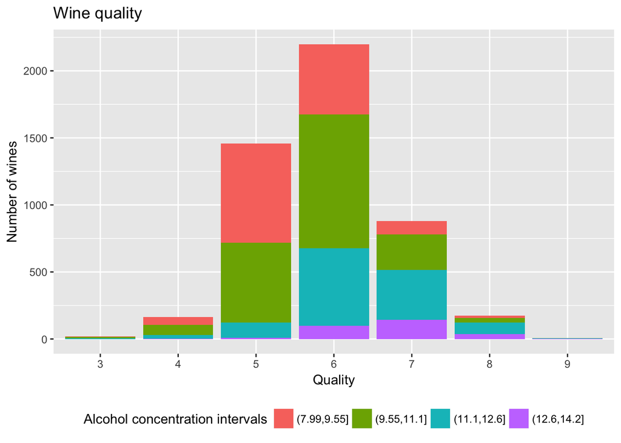

### Description One

The majority of wines in the dataset is rated between 5 and 7, with 6 being the most frequent rating. Wines included in average to above-average rating categories (>= 6) tend to have a higher concentration of alcohol.

### Plot Two

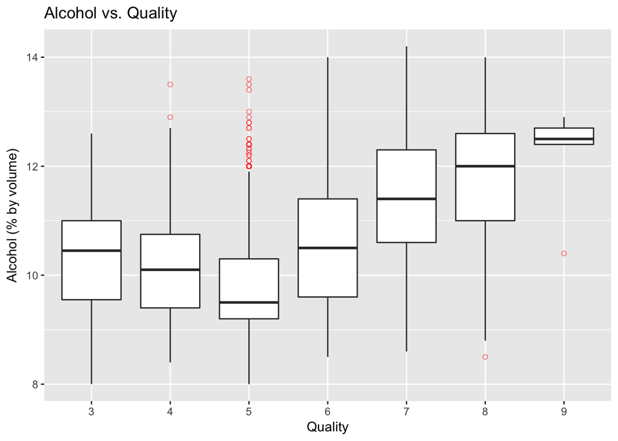

### Plot Three

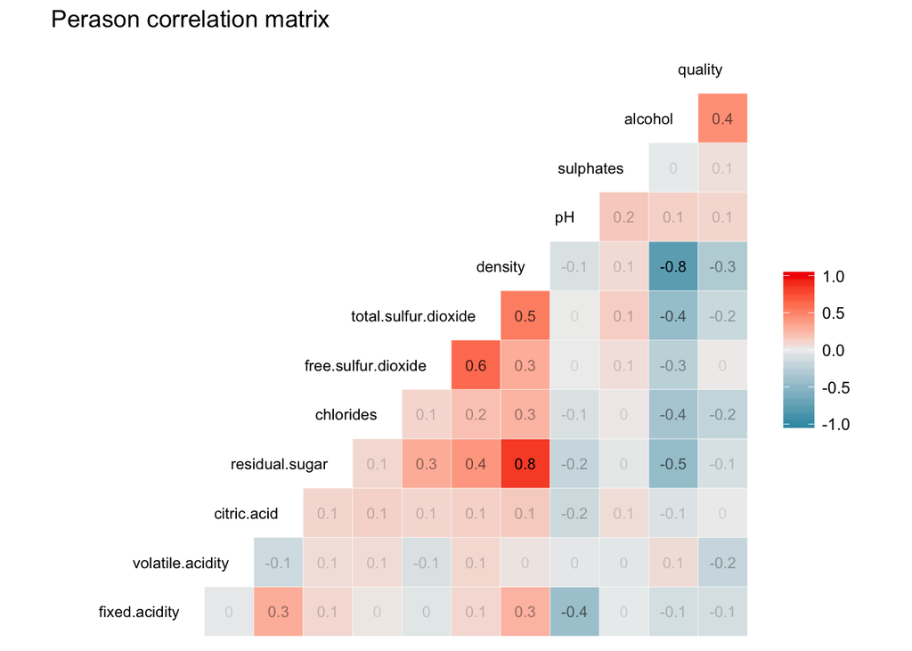

### Description Three

The correlation matrix clearly shows that quality is only really correlated with alcohol and density. All other variables are not correlated with quality.

# Reflection

When reflecting on my analysis of the wine dataset, the following points come to mind:

### Path of analysis

I started by examining every single variable in the dataset and formulated hypotheses on which variables could be significant in predicting wine quality. After calculating correlations, I found out that actually only alcohol (and density) had some correlation with quality. Therefore I based my linear models on these variables (and the factors I created from them).

### Challlenges

- As most of the (chemical) variables of the wine dataset were unknown to me, before starting with data exploration, I had familiarize myself with their meaning
- In the beginning I used histograms for every visualization in univariate analysis and played with bin width. I realized only later that freqpoly plots have some advantage of histograms when the variable of interest is dispersed over a wide range of values
- It took me some time to best deal with log10 transformed x-axis

### Successes

- The correlation matrix I created with ggcorr was very helpful for further analysis.
- I found geom_smooth() to be very helpful in visualizing trends in the data.

### Surprising observations

- Before starting my analysis, that the dataset would contain more variables that were highly correlated with wine quality. It was a bit disappointing to have only alcohol to play with.

### Recommendations for future work

- It would be great to incorporate further (economic) variables (price, quantity sold, origin of wine, etc.) into the dataset to investigate quality from a different angle.

# Resources

- [R documentation](https://www.r-project.org/other-docs.html)
- [ggplot2 documentation](http://ggplot2.tidyverse.org/reference/)
- [GGally documentation](http://ggobi.github.io/ggally/#ggally)
- [tidyverse documentation](http://tidyverse.org/)